# Shopify Rscript

Deji Sulola

2/26/2022

# QUESTION 1:

Given some sample data, write a program to answer the following: click [here](https://docs.google.com/spreadsheets/d/16i38oonuX1y1g7C_UAmiK9GkY7cS-64DfiDMNiR41LM/edit#gid=0) to access the required data set

On Shopify, we have exactly 100 sneaker shops, and each of these shops sells only one model of shoe. We want to do some analysis of the average order value (AOV). When we look at orders data over a 30 day window, we naively calculate an AOV of $3145.13. Given that we know these shops are selling sneakers, a relatively affordable item, something seems wrong with our analysis.

#### What could be wrong with our intial AOV value?

For this investigation, we take a deep-dive into our sales data to have a full understanding of what went wrong and how we can correct for the error (if any). First, we load our libraries, then sales data. We find that the previously calculated AOV of $3145.13 was derived through taking an average of the sum of total order amount for all stores.

```r
library(tidyverse)
library(dplyr)
library(readxl)
setwd("/Users/dejisulola/Downloads")
Shops <- read_excel("2019 Winter Data Science Intern Challenge Data Set.xlsx")
head(Shops,10)
```

```
## # A tibble: 10 × 7
##    order_id shop_id user_id order_amount total_items payment_method
##       <dbl>   <dbl>   <dbl>        <dbl>       <dbl> <chr>
##  1        1      53     746          224           2 cash
##  2        2      92     925           90           1 cash
##  3        3      44     861          144           1 cash
##  4        4      18     935          156           1 credit_card
##  5        5      18     883          156           1 credit_card
##  6        6      58     882          138           1 credit_card
##  7        7      87     915          149           1 cash
##  8        8      22     761          292           2 cash
##  9        9      64     914          266           2 debit
## 10       10      52     788          146           1 credit_card
## # … with 1 more variable: created_at <dttm>
```

```r
summary(Shops$order_amount)
```

```
##    Min. 1st Qu.  Median    Mean 3rd Qu.    Max.
##      90     163     284    3145     390  704000
```

#### What is the best way to evaluate the data?

Getting the correct average order value requires that we standardize our total order value by the quantity of Sneakers sold (this the first source of problem in our prior analysis). Hence, we create a new variable called CPU (Cost per Unit) which is simply the total order value divided by the quantity order. This new variable reflects the price per sneakers for each shop, after which we can comfortably take a total average for all shops.

```r
Shops_ <- mutate(Shops,CPU = Shops$order_amount/Shops$total_items)
summary(Shops_$CPU)
```

```
##    Min. 1st Qu.  Median    Mean 3rd Qu.    Max.
##    90.0   133.0   153.0   387.7   169.0 25725.0
```

We arrive at a technically correct Average Order Value of $387.7. But comparing our AOV with some of the CPU values we saw earlier, we can tell the AOV is very high which is not expected considering the mean is always supposed to be at the center of the distribution. Therefore, we construct an histogram to see the distribution of the CPU and discover Store 78 has a very high CPU and is the source of the skewness in the mean.

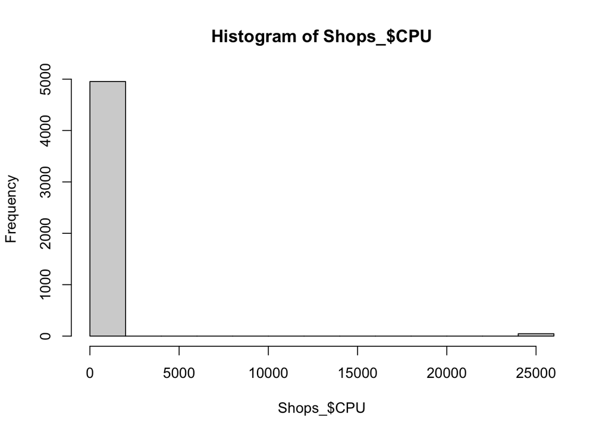

```r
hist(Shops_$CPU)
```

```r
Check <- filter(Shops_, Shops_$CPU > 387)
Check$shop_id
```

```
##  [1] 78 78 78 78 78 78 78 78 78 78 78 78 78 78 78 78 78 78 78 78 78 78 78 78 78
## [26] 78 78 78 78 78 78 78 78 78 78 78 78 78 78 78 78 78 78 78 78 78
```

```r
Shops_$class <- ifelse(Shops_$CPU < 353, "B",
                ifelse(Shops_$CPU > 353, "A", "X"))
Shops_
```

```
## # A tibble: 5,000 × 9
##    order_id shop_id user_id order_amount total_items payment_method
##       <dbl>   <dbl>   <dbl>        <dbl>       <dbl> <chr>
##  1        1      53     746          224           2 cash
##  2        2      92     925           90           1 cash
##  3        3      44     861          144           1 cash
##  4        4      18     935          156           1 credit_card
##  5        5      18     883          156           1 credit_card
##  6        6      58     882          138           1 credit_card
##  7        7      87     915          149           1 cash
##  8        8      22     761          292           2 cash
##  9        9      64     914          266           2 debit
## 10       10      52     788          146           1 credit_card
## # … with 4,990 more rows, and 3 more variables: created_at <dttm>, CPU <dbl>,
## #   class <chr>
```

#### What is the best Metric?

```r
Shops_ %>%
  group_by(class) %>%
  summarize(AOV = mean(CPU))
```

```
## # A tibble: 2 × 2
##   class    AOV
##   <chr>  <dbl>
## 1 A     25725
## 2 B       152.
```

```r
Shops_ %>%
  group_by(class) %>%
  tally()
```

```
## # A tibble: 2 × 2
##   class     n
##   <chr> <int>
## 1 A        46
## 2 B      4954
```

##### What is the Value?

From this, we can then arrive at a proper AOV - $152.5 (excluding shop 78). This gives a proper representation for management actions.

# QUESTION 2:

For this question you’ll need to use SQL. Follow this [link](https://www.w3schools.com/SQL/TRYSQL.ASP?FILENAME=TRYSQL_SELECT_ALL) to access the data set required for the challenge. Please use queries to answer the following questions.

#### A. How many orders were shipped by Speedy Express in total?

```sql
SELECT shp.ShipperName, ord.ShipperID, SUM(ordt.Quantity) AS TotalQuantity
FROM OrderDetails ordt, Orders ord, Shippers shp
WHERE ord.ShipperID = shp.ShipperID AND ord.OrderID=ordt.OrderID AND shp.ShipperName = 'Speedy Express';
```

Total Number of orders shipped by Speedy Express is 3575. The needed data points for this question is scattered across three tables (Order Details, Orders and Shippers). We derive this by selecting and matching the keys from the tables, summing the quantity ordered and then we filter the shipper names (selecting only Speedy Express).

#### B. What is the last name of the employees with the most orders?

```sql
SELECT ord.OrderID, ordt.Quantity, ep.EmployeeID, ep.LastName, SUM(ordt.Quantity) AS TotalOrders
FROM OrderDetails ordt, Orders ord, Employees ep
where ordt.OrderID = ord.OrderID AND ord.EmployeeID = ep.EmployeeID
GROUP BY (LastName)
ORDER BY TotalOrders DESC
LIMIT 1;
```

We find that Peacock is the employee with the most orders - 3232 orders. Similar to the first question, we combine keys from 3 separate tables (OrderDetails, Orders and Employees). Then, we match the unique identifiers from the tables, sum up and sort the quantity of orders and group by employee’s last name. The limit function is tuned to 1, to give us the highest number of orders.

#### C. What product was ordered the most by customers in Germany?

```sql
SELECT cm.Country, ordt.ProductID, pd.ProductName, SUM(ordt.Quantity) AS TotalOrder
FROM Customers cm, OrderDetails ordt, Orders ord, Products pd
WHERE cm.CustomerID=ord.CustomerID AND ordt.ProductID=Pd.ProductID AND ord.OrderID=ordt.OrderID AND cm.Country ='Germany'
GROUP BY ProductName
ORDER BY TotalOrder DESC
LIMIT 1;
```

Boston Crab Meat was ordered the most by customers in Germany. We combined keys from four tables (Customers, OrderDetails, Orders and Products) and then we filter the country by “Germany”, sum ap and rank the quantity ordered and finally we group by the product name to see what was ordered for each products.